# Assignment 3 demonstration: a simulated signalised-grid traffic dataset

ITI5145 Foundations of Data Science, Monash University

[STUDENT_NAME] ([STUDENT_ID])

03 October 2026

# 1 Dataset description

**What the project is.** The proposed project is a *digital twin* of a small road network: a 2 x 2 grid of signalised junctions (left-hand traffic, two lanes per direction, 200 m blocks) in which cars follow the Intelligent Driver Model and each junction’s traffic light is driven by a controller. The aim is to learn a signal controller from data (imitation of a *max-pressure* rule that is also aware of ambulances) and to evaluate it in closed loop.

**Where the data comes from.** No public dataset logs the internal state of a traffic signal together with the queues on every approach at every decision instant, so the dataset was *generated* with the project’s own simulator (`traffic_twin`, Python). Everything about the generating process (physics, signals, calibration of demand levels, random seeds, scenario mixture) is recorded in the data card `DATACARD.md` that ships with the data, and every column of every table is described in `data_dictionary.csv`. The simulator is deterministic: episode `i` uses seed `100000 + i`, so any row can be regenerated.

## 1.1 Release front matter

The identity of a release is the pair (generator version, configuration hash) written to `config.json`; the head line of the data card repeats the row counts. Both are read here, not typed.

```r
cfg  <- fromJSON(file.path(data_dir, "config.json"))
card <- readLines(file.path(data_dir, "DATACARD.md"))
head_line <- card[grep("generator_version", card)[1]]
grab <- function(pattern) as.integer(sub(paste0(".*?([0-9]+) ", pattern, ".*"), "\\1", head_line, perl = TRUE))
card_counts <- c(episodes = grab("episodes"), signal_ticks = grab("signal_ticks rows"), vehicles = grab("vehicles"))

front <- data.frame(
  item  = c("dataset", "generator_version", "config_hash", "episodes (data card)",
            "signal_ticks rows (data card)", "vehicles (data card)", "licence",
            "download link", "data card / dictionary"),
  value = c(basename(normalizePath(data_dir)), cfg$generator_version,
            sub(".*config_hash `([0-9a-f]+)`.*", "\\1", head_line),
            format(card_counts["episodes"], big.mark = ","),
            format(card_counts["signal_ticks"], big.mark = ","),
            format(card_counts["vehicles"], big.mark = ","),
            "CC BY 4.0 for the data, MIT for the generator code (proposed; synthetic data, no personal information)",
            "[DATASET_DOWNLOAD_LINK]",
            "DATACARD.md, data_dictionary.csv (shipped with the CSV files)"),
  row.names = NULL)
kable(front, caption = "Release front matter (read from config.json and DATACARD.md)")
```

Release front matter (read from config.json and DATACARD.md)

| item | value |
| --- | --- |
| dataset | traffic_v1 |
| generator_version | traffic_twin_v1.2 |
| config_hash | ecd36a4b3cad |
| episodes (data card) | 120 |
| signal_ticks rows (data card) | 300,598 |
| vehicles (data card) | 360,443 |
| licence | CC BY 4.0 for the data, MIT for the generator code (proposed; synthetic data, no personal information) |
| download link | [DATASET_DOWNLOAD_LINK] |
| data card / dictionary | DATACARD.md, data_dictionary.csv (shipped with the CSV files) |

**Download link:** [DATASET_DOWNLOAD_LINK]

The release contains five tables (CSV):

| file | one row per | what it holds |
| --- | --- | --- |
| `episodes.csv` | episode | the scenario settings (demand level, controller, sensor noise, ambulance rate, split) and the KPIs of the episode |
| `vehicles.csv` | vehicle | route, travel time, delay, stops, and the vehicle’s *hidden* driver parameters |
| `signal_ticks.csv` | junction x decision instant | **the machine-learning table**: what the controller could see, what it did, and two labels (`y_mp_action`, `y_q_total_t30`) |
| `junction_1hz.csv` | junction x second | queue and vehicle totals at 1 Hz, used to build the 30 s-ahead label |
| `network_edges.csv` | directed road edge | geometry and storage of each link |

Each episode is 300 s warm-up + 3600 s main period + 300 s cool-down. Rows inside the warm-up, the cool-down and the last 30 s of the main period (the “tail”) are flagged and excluded from training.

## 1.2 File integrity (checksums)

If the release ships a `SHA256SUMS.txt`, every file is hashed again here and compared with it, so a reader can tell that the download is the file that was analysed.

```r
# results="asis": cat() writes Markdown and the tables inside the if-blocks render as tables
sums_path <- file.path(data_dir, "SHA256SUMS.txt")
if (!file.exists(sums_path)) {
  cat("No `SHA256SUMS.txt` in `", data_dir, "`: checksum comparison skipped.\n\n", sep = "")
} else if (!requireNamespace("digest", quietly = TRUE)) {
  # fallback: list the md5 of each file (cannot be compared with a sha256 list)
  files <- read.table(sums_path, col.names = c("sha256_expected", "file"))$file
  cat(kable(data.frame(file = files, md5 = unname(tools::md5sum(file.path(data_dir, files)))),
            caption = "digest not installed: md5 of each file (not comparable with SHA256SUMS.txt)"), sep = "\n")
} else {
  sums <- read.table(sums_path, col.names = c("sha256_expected", "file"), stringsAsFactors = FALSE)
  sums$size_MB <- round(file.size(file.path(data_dir, sums$file)) / 1e6, 1)
  sums$sha256_computed <- sapply(sums$file, function(f) digest::digest(file = file.path(data_dir, f), algo = "sha256"))
  sums$match <- sums$sha256_expected == sums$sha256_computed
  short <- function(h) paste0(substr(h, 1, 12), "...")
  cat(kable(data.frame(file = sums$file, size_MB = sums$size_MB, expected = short(sums$sha256_expected),
                       computed = short(sums$sha256_computed), match = sums$match),
            caption = "SHA-256 of each released file vs SHA256SUMS.txt (first 12 hex digits shown)"), sep = "\n")
  cat("\n**All checksums match:**", all(sums$match), "\n\n")
}
```

SHA-256 of each released file vs SHA256SUMS.txt (first 12 hex digits shown)

| file | size_MB | expected | computed | match |
| --- | --- | --- | --- | --- |
| episodes.csv | 0.0 | 5ea49f6d4b8b… | 5ea49f6d4b8b… | TRUE |
| vehicles.csv | 83.2 | 2f20a4127ae9… | 2f20a4127ae9… | TRUE |
| signal_ticks.csv | 102.1 | e2454b2f83be… | e2454b2f83be… | TRUE |
| junction_1hz.csv | 52.4 | 3c90f368f8fd… | 3c90f368f8fd… | TRUE |
| network_edges.csv | 0.0 | 0f11ab4e1d22… | 0f11ab4e1d22… | TRUE |
| data_dictionary.csv | 0.0 | 9edb99c68136… | 9edb99c68136… | TRUE |
| config.json | 0.0 | d03f7eab79b7… | d03f7eab79b7… | TRUE |

**All checksums match:** TRUE

# 2 Loading and structure

## 2.1 Reading the tables

The CSV files were written by Python, so boolean columns contain the strings `True` / `False`. A small helper turns those into R logicals.

```r
fix_bool <- function(df) {
  # convert character columns that only contain "True"/"False" to logical
  for (col in names(df)) {
    x <- df[[col]]
    if (is.character(x) && all(x %in% c("True", "False"))) df[[col]] <- (x == "True")
  }
  df
}

t0 <- Sys.time()
ep  <- fix_bool(read.csv(file.path(data_dir, "episodes.csv")))
vh  <- fix_bool(read.csv(file.path(data_dir, "vehicles.csv")))
st  <- fix_bool(read.csv(file.path(data_dir, "signal_ticks.csv")))
jz  <- read.csv(file.path(data_dir, "junction_1hz.csv"))
net <- fix_bool(read.csv(file.path(data_dir, "network_edges.csv")))
dd  <- fix_bool(read.csv(file.path(data_dir, "data_dictionary.csv")))
ep$ev_rate <- as.character(ep$ev_rate)       # "0" / "default", keep as text
cat("Loaded in", round(as.numeric(difftime(Sys.time(), t0, units = "secs")), 1), "seconds\n")
```

## 2.2 Dimensions and column types

```r
tables <- list(episodes = ep, vehicles = vh, signal_ticks = st, junction_1hz = jz, network_edges = net)
dims <- data.frame(table = names(tables),
                   rows = sapply(tables, nrow),
                   columns = sapply(tables, ncol),
                   size_MB = round(sapply(tables, function(d) as.numeric(object.size(d))) / 1e6, 1),
                   row.names = NULL)
kable(dims, caption = "Rows and columns of each table as loaded in R")
```

Rows and columns of each table as loaded in R

| table | rows | columns | size_MB |
| --- | --- | --- | --- |
| episodes | 120 | 66 | 0.1 |
| vehicles | 360443 | 29 | 70.7 |
| signal_ticks | 300598 | 80 | 115.4 |
| junction_1hz | 1996932 | 7 | 63.9 |
| network_edges | 24 | 18 | 0.0 |

So the release holds 120 episodes, 360,443 vehicles, 300,598 decision rows and 1,996,932 one-second junction rows.

`str()` of the key columns of the two tables used most, the episode table and the ML table (the ML table has 80 columns, so only a few are shown):

```r
str(ep[, c("episode_id", "seed", "demand_level", "controller", "sensor_noise_level",
           "ev_rate", "split", "mean_total_delay_s", "throughput_vph", "n_invariant_violations")])
```

```
## 'data.frame':    120 obs. of  10 variables:
##  $ episode_id            : int  0 1 2 3 4 5 6 7 8 9 ...
##  $ seed                  : int  100000 100001 100002 100003 100004 100005 100006 100007 100008 100009 ...
##  $ demand_level          : chr  "design" "low" "design" "low" ...
##  $ controller            : chr  "fixed_time" "max_pressure" "max_pressure" "max_pressure" ...
##  $ sensor_noise_level    : num  0 0.1 0 0 0.1 0.1 0.1 0 0.1 0.1 ...
##  $ ev_rate               : chr  "0" "0" "default" "0" ...
##  $ split                 : chr  "train" "train" "train" "train" ...
##  $ mean_total_delay_s    : num  98.3 49.6 63.8 46.9 600.4 ...
##  $ throughput_vph        : num  2408 1593 2433 1583 3160 ...
##  $ n_invariant_violations: int  0 0 0 0 0 0 0 0 0 0 ...
```

```r
str(st[, c("episode_id", "junction_id", "t", "is_warmup", "phase", "time_in_phase_s",
           "q_N", "n_N", "down_n_N", "ev_present_N", "action_applied", "y_mp_action", "y_q_total_t30")])
```

```
## 'data.frame':    300598 obs. of  13 variables:
##  $ episode_id     : int  0 0 0 0 0 0 0 0 0 0 ...
##  $ junction_id    : int  0 1 2 3 0 1 2 3 0 1 ...
##  $ t              : num  5 5 5 5 10 10 10 10 15 15 ...
##  $ is_warmup      : logi  TRUE TRUE TRUE TRUE TRUE TRUE ...
##  $ phase          : int  0 0 0 0 0 0 0 0 0 0 ...
##  $ time_in_phase_s: num  5 5 5 5 10 10 10 10 15 15 ...
##  $ q_N            : int  0 0 0 0 0 0 0 0 0 0 ...
##  $ n_N            : int  0 0 0 0 0 0 2 0 0 0 ...
##  $ down_n_N       : int  0 0 0 0 0 0 0 0 0 0 ...
##  $ ev_present_N   : logi  FALSE FALSE FALSE FALSE FALSE FALSE ...
##  $ action_applied : int  0 0 0 0 0 0 0 0 0 0 ...
##  $ y_mp_action    : int  0 0 0 0 0 0 0 0 0 0 ...
##  $ y_q_total_t30  : num  7 1 2 0 10 1 5 2 12 2 ...
```

```r
summary(ep[, c("mean_total_delay_s", "p90_total_delay_s", "throughput_vph",
               "max_queue_veh", "switches_per_min", "n_red_commits")])
```

```
##  mean_total_delay_s p90_total_delay_s throughput_vph max_queue_veh
##  Min.   : 44.57     Min.   :  91.37   Min.   :1142   Min.   : 11.00
##  1st Qu.: 69.60     1st Qu.: 121.03   1st Qu.:1739   1st Qu.: 23.00
##  Median :100.99     Median : 164.02   Median :2702   Median : 37.00
##  Mean   :210.50     Mean   : 365.10   Mean   :2550   Mean   : 62.67
##  3rd Qu.:304.19     3rd Qu.: 532.87   3rd Qu.:3066   3rd Qu.:113.25
##  Max.   :885.82     Max.   :1550.29   Max.   :3736   Max.   :186.00
##  switches_per_min n_red_commits
##  Min.   :0.850    Min.   : 123.0
##  1st Qu.:2.500    1st Qu.: 290.8
##  Median :4.206    Median : 613.5
##  Mean   :3.741    Mean   : 755.4
##  3rd Qu.:4.497    3rd Qu.:1196.5
##  Max.   :4.979    Max.   :1803.0
```

```r
summary(vh[, c("travel_time_s", "total_delay_s", "n_stops", "alpha", "v0_mps")])
```

```
##  travel_time_s    total_delay_s        n_stops           alpha
##  Min.   :   0.0   Min.   : -47.17   Min.   : 0.000   Min.   :0.001555
##  1st Qu.:  99.5   1st Qu.:  67.27   1st Qu.: 1.000   1st Qu.:0.328515
##  Median : 162.0   Median : 130.79   Median : 2.000   Median :0.503330
##  Mean   : 234.2   Mean   : 252.27   Mean   : 3.926   Mean   :0.504403
##  3rd Qu.: 315.5   3rd Qu.: 343.94   3rd Qu.: 5.000   3rd Qu.:0.678506
##  Max.   :1755.0   Max.   :2359.23   Max.   :23.000   Max.   :1.000000
##      v0_mps
##  Min.   :11.81
##  1st Qu.:13.05
##  Median :13.90
##  Mean   :13.95
##  3rd Qu.:14.81
##  Max.   :17.38
```

## 2.3 Cross-check against the data card and the data dictionary

The row counts are compared with the head line of the data card (a printed check, because a re-generated release changes them), and the data dictionary is compared with the files: if they agree, the number of dictionary rows per table equals the number of columns and every column name is documented. The `stopifnot()` calls only guard *structural* facts (unique keys, every column documented), which must hold for any release.

```r
count_check <- data.frame(table = names(card_counts),
                          rows_in_file = c(nrow(ep), nrow(st), nrow(vh)),
                          rows_in_data_card = unname(card_counts))
count_check$match <- count_check$rows_in_file == count_check$rows_in_data_card
kable(count_check, caption = "Row counts: files vs the head line of DATACARD.md")
```

Row counts: files vs the head line of DATACARD.md

| table | rows_in_file | rows_in_data_card | match |
| --- | --- | --- | --- |
| episodes | 120 | 120 | TRUE |
| signal_ticks | 300598 | 300598 | TRUE |
| vehicles | 360443 | 360443 | TRUE |

```r
dict_counts <- dd %>% count(table, name = "columns_in_dictionary")
file_counts <- data.frame(table = names(tables), columns_in_file = sapply(tables, ncol), row.names = NULL)
check <- full_join(file_counts, dict_counts, by = "table") %>%
  rowwise() %>%
  mutate(undocumented = {
    cols <- names(tables[[table]])
    if (is.na(columns_in_dictionary)) NA_integer_ else sum(!cols %in% dd$column[dd$table == table])
  }) %>% ungroup()
kable(check, caption = "Columns per table: file vs data dictionary")
```

Columns per table: file vs data dictionary

| table | columns_in_file | columns_in_dictionary | undocumented |
| --- | --- | --- | --- |
| episodes | 66 | 66 | 0 |
| vehicles | 29 | 29 | 0 |
| signal_ticks | 80 | 80 | 0 |
| junction_1hz | 7 | 7 | 0 |
| network_edges | 18 | 18 | 0 |

```r
# structural facts: primary keys unique, every column of every table documented
stopifnot(!any(duplicated(ep$episode_id)),
          !any(duplicated(st[, c("episode_id", "junction_id", "t")])),
          !any(duplicated(vh[, c("episode_id", "veh_id")])),
          all(check$undocumented == 0, na.rm = TRUE))
cat("Primary keys are unique and every column is documented.\n")
```

```
## Primary keys are unique and every column is documented.
```

## 2.4 The features of the ML table

`signal_ticks.csv` is the table a controller model learns from. The data dictionary tags every column with a *namespace* and with `twin_observable`, which says whether the digital twin could present that column to a controller at run time. Keys, time stamps, the controller’s own actions and the labels are not observable; everything else is a legitimate feature.

```r
ns <- dd %>% filter(table == "signal_ticks") %>%
  group_by(namespace, twin_observable) %>%
  summarise(columns = n(),
            examples = paste(head(column, 4), collapse = ", "),
            .groups = "drop") %>%
  arrange(desc(twin_observable), desc(columns))
kable(ns, caption = "signal_ticks columns by namespace (full dictionary in the appendix)")
```

signal_ticks columns by namespace (full dictionary in the appendix)

| namespace | twin_observable | columns | examples |
| --- | --- | --- | --- |
| state | TRUE | 20 | q_N, n_N, q_N_l0, q_N_l1 |
| ev | TRUE | 16 | ev_present_N, ev_dist_N, ev_eta_N, ev_q_ahead_N |
| downstream | TRUE | 12 | down_n_N, down_occ_N, down_blocked_N, down_n_E |
| neighbour | TRUE | 12 | nb_N_exists, nb_N_phase, nb_N_green_toward_me, nb_E_exists |
| sensor | TRUE | 4 | obs_q_N, obs_q_E, obs_q_S, obs_q_W |
| signal | TRUE | 3 | phase, time_in_phase_s, max_green_remaining_s |
| time | FALSE | 5 | t, tick_idx, is_warmup, is_cooldown |
| action | FALSE | 4 | action_requested, action_applied, forced, switched |
| key | FALSE | 2 | episode_id, junction_id |
| label | FALSE | 2 | y_mp_action, y_q_total_t30 |

```r
cat("Observable feature columns:", sum(ns$columns[ns$twin_observable]),
    " non-feature columns:", sum(ns$columns[!ns$twin_observable]), "\n")
```

```
## Observable feature columns: 67  non-feature columns: 13
```

In words: the `signal` namespace is the state of the light (which approach is green and for how long), `state` holds the queue and vehicle counts per approach and lane plus the arrivals of the last 30 s, `downstream` says how full and whether blocked each exit link is, `neighbour` is the phase of the adjacent junction, `ev` is the GPS-style ambulance channel and `sensor` is a noisy copy of the four queue lengths (`obs_q_*`). The full table with data types, units and null policy is in the appendix.

## 2.5 Missingness

```r
na_table <- function(d, name) {
  n <- colSums(is.na(d))
  n <- n[n > 0]
  if (length(n) == 0) return(data.frame(table = name, column = "(none)", n_missing = 0, share = 0))
  data.frame(table = name, column = names(n), n_missing = as.integer(n), share = round(n / nrow(d), 4), row.names = NULL)
}
bind_rows(na_table(ep, "episodes"), na_table(vh, "vehicles"),
          na_table(st, "signal_ticks"), na_table(jz, "junction_1hz")) %>%
  kable(caption = "Columns with missing values (all others are complete)")
```

Columns with missing values (all others are complete)

| table | column | n_missing | share |
| --- | --- | --- | --- |
| episodes | gridlock_t | 117 | 0.9750 |
| episodes | spillback_lock_t | 117 | 0.9750 |
| episodes | ev_mean_travel_time_s | 36 | 0.3000 |
| episodes | ev_mean_delay_s | 36 | 0.3000 |
| episodes | ev_p90_delay_s | 36 | 0.3000 |
| episodes | ev_mean_stops | 36 | 0.3000 |
| episodes | car_mean_delay_penalty_s | 36 | 0.3000 |
| episodes | recovery_time_s | 36 | 0.3000 |
| vehicles | enter_t | 8471 | 0.0235 |
| vehicles | exit_t | 22292 | 0.0618 |
| signal_ticks | y_q_total_t30 | 25312 | 0.0842 |
| junction_1hz | (none) | 0 | 0.0000 |

The missing values are all *by design*: the ambulance KPIs are `NA` in episodes without ambulances, `gridlock_t` is `NA` when no gridlock happened, `enter_t` is `NA` for vehicles that were still waiting in an entry queue when the episode ended (they never entered the network), `exit_t` is `NA` for those and for vehicles still on the network at the end, and the regression label `y_q_total_t30` looks 30 s ahead, so it cannot exist on the last 30 s of the main period or in the cool-down. We verify the last claim directly:

```r
st %>%
  mutate(period = case_when(is_warmup ~ "warm-up", is_cooldown ~ "cool-down",
                            is_tail ~ "tail (last 30 s)", TRUE ~ "main")) %>%
  group_by(period) %>%
  summarise(rows = n(), label_missing = sum(is.na(y_q_total_t30)),
            share_missing = round(mean(is.na(y_q_total_t30)), 4)) %>%
  kable(caption = "y_q_total_t30 missingness by period")
```

y_q_total_t30 missingness by period

| period | rows | label_missing | share_missing |
| --- | --- | --- | --- |
| cool-down | 23201 | 23201 | 1e+00 |
| main | 253275 | 28 | 1e-04 |
| tail (last 30 s) | 2083 | 2083 | 1e+00 |
| warm-up | 22039 | 0 | 0e+00 |

```r
missing_main <- st %>% filter(!is_warmup, !is_cooldown, !is_tail, is.na(y_q_total_t30)) %>% count(episode_id)
gridlock_eps <- ep$episode_id[ep$gridlock]
if (nrow(missing_main) == 0) {
  cat("No main-period row is missing the regression label.\n\n")
} else {
  cat("Main-period rows without `y_q_total_t30`, by episode (episodes that ended early by the gridlock rule: ",
      if (length(gridlock_eps)) paste(gridlock_eps, collapse = ", ") else "none", "):\n\n", sep = "")
  cat(kable(missing_main, caption = "Main-period rows without the regression label"), sep = "\n")
}
```

Main-period rows without `y_q_total_t30`, by episode (episodes that ended early by the gridlock rule: 20, 74, 93):

Main-period rows without the regression label

| episode_id | n |
| --- | --- |
| 74 | 14 |
| 93 | 14 |

A main-period row can only lack the label when the episode ended early by the gridlock rule, so the last 30 s before the stop have no future to look at; that is the case for episode(s) 74, 93.

```r
# the training population: main-period rows with none of the three flags set
main <- st %>% filter(!is_warmup, !is_cooldown, !is_tail) %>%
  left_join(ep %>% select(episode_id, demand_level, controller, split, sensor_noise_level, ev_rate),
            by = "episode_id")
cat("Main-period rows:", nrow(main), "of", nrow(st), "\n")
```

```
## Main-period rows: 253275 of 300598
```

# 3 Basic characteristics

## 3.1 Episode mix and splits

```r
lvl <- c("low", "design", "high", "stress")
ep %>% count(demand_level, controller) %>%
  pivot_wider(names_from = controller, values_from = n, values_fill = 0) %>%
  arrange(factor(demand_level, levels = lvl)) %>%
  kable(caption = "Episodes by demand level and controller")
```

Episodes by demand level and controller

| demand_level | fixed_time | max_pressure | max_pressure_eps | random_dwell |
| --- | --- | --- | --- | --- |
| low | 4 | 15 | 8 | 3 |
| design | 9 | 24 | 10 | 5 |
| high | 9 | 4 | 13 | 4 |
| stress | 2 | 5 | 5 | 0 |

```r
ep %>% count(split) %>% kable(caption = "Episodes per split (stress demand is held out as test_ood)")
```

Episodes per split (stress demand is held out as test_ood)

| split | n |
| --- | --- |
| test | 15 |
| test_ood | 12 |
| train | 79 |
| val | 14 |

```r
ep %>% count(ev_rate, sensor_noise_level) %>% kable(caption = "Episodes by ambulance rate and sensor noise level")
```

Episodes by ambulance rate and sensor noise level

| ev_rate | sensor_noise_level | n |
| --- | --- | --- |
| 0 | 0.0 | 23 |
| 0 | 0.1 | 13 |
| default | 0.0 | 49 |
| default | 0.1 | 35 |

## 3.2 Delay distribution by demand level

Per-vehicle total delay = entry-queue wait + travel time - free-flow time, for cars spawned in the main period. **Rule for the delay figures.** Delay is right-skewed and spans two orders of magnitude, so every delay plot uses a log axis, and a log axis cannot show values at or below zero. The plots therefore keep only delays of at least 1 s; the vehicles dropped by that rule are counted below and are included in every *table* (which uses all cars). A delay below 1 s means the vehicle met no queue and no red light; a negative delay would mean that it drove faster than the free-flow reference (the reference uses the per-vehicle desired speed and a fixed turn penalty, so small negative values are possible in principle).

```r
cars <- vh %>% filter(!is_warmup, vehicle_type == "car") %>%
  left_join(ep %>% select(episode_id, demand_level, controller, ev_rate, demand_asym), by = "episode_id") %>%
  mutate(demand_level = factor(demand_level, levels = lvl))
delay_min <- 1                                   # plotting threshold [s]
rule <- data.frame(
  cars_main_period = nrow(cars),
  delay_negative = sum(cars$total_delay_s < 0, na.rm = TRUE),
  delay_below_1s = sum(cars$total_delay_s < delay_min, na.rm = TRUE),
  delay_missing = sum(is.na(cars$total_delay_s)),
  kept_for_plots = sum(cars$total_delay_s >= delay_min, na.rm = TRUE))
kable(rule, caption = "Cars affected by the plotting rule (delay >= 1 s); tables use all cars")
```

Cars affected by the plotting rule (delay >= 1 s); tables use all cars

| cars_main_period | delay_negative | delay_below_1s | delay_missing | kept_for_plots |
| --- | --- | --- | --- | --- |
| 329727 | 36 | 61 | 0 | 329666 |

```r
share_dropped <- 1 - rule$kept_for_plots / rule$cars_main_period
```

The plotting rule drops 61 cars (0.02% of the main-period cars), of which 36 have a negative delay.

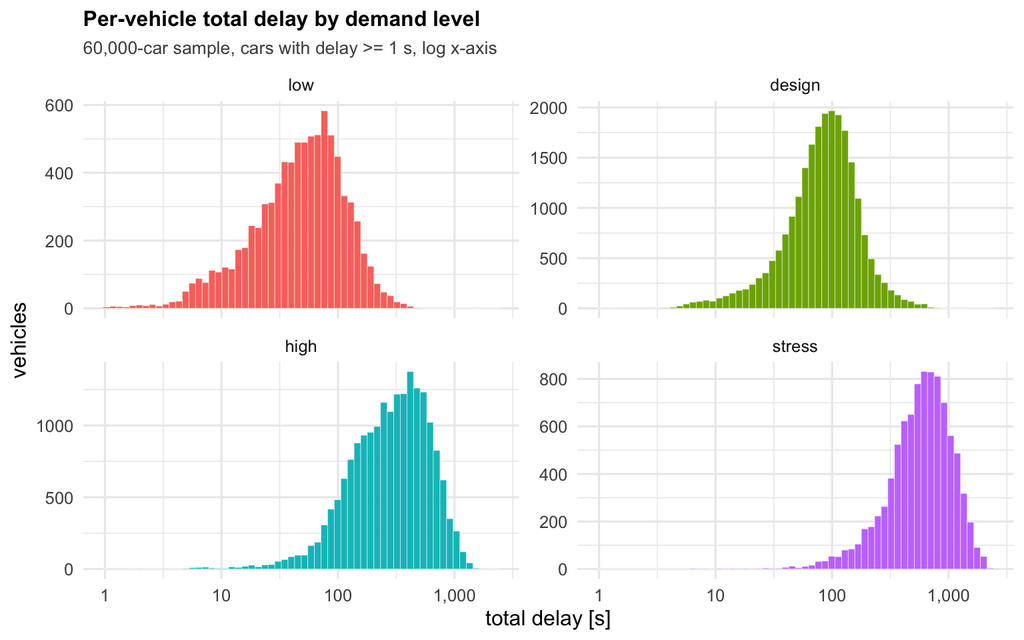

```r
n_sample <- min(60000, rule$kept_for_plots)
cars_plot <- cars %>% filter(total_delay_s >= delay_min) %>% slice_sample(n = n_sample)   # cap for plotting
ggplot(cars_plot, aes(total_delay_s, fill = demand_level)) +
  geom_histogram(bins = 60, colour = "white", linewidth = 0.1) +
  scale_x_log10(labels = label_comma()) +
  facet_wrap(~ demand_level, ncol = 2, scales = "free_y") +
  labs(title = "Per-vehicle total delay by demand level",
       subtitle = sprintf("%s-car sample, cars with delay >= %d s, log x-axis", format(n_sample, big.mark = ","), delay_min),
       x = "total delay [s]", y = "vehicles") +
  theme(legend.position = "none")
```

The table separates *finished* trips (`completed == TRUE`, the vehicle left the network before the episode ended) from *unfinished* ones (still on the network or still in an entry queue at the end), whose delay is censored and would otherwise be mixed with the finished trips.

```r
cars %>%
  mutate(trip = ifelse(completed, "finished", "unfinished")) %>%
  group_by(demand_level, trip) %>%
  summarise(vehicles = n(), mean_delay_s = round(mean(total_delay_s, na.rm = TRUE), 1),
            median_delay_s = round(median(total_delay_s, na.rm = TRUE), 1),
            p90_delay_s = round(quantile(total_delay_s, 0.9, na.rm = TRUE), 1), .groups = "drop") %>%
  kable(caption = "Delay statistics by demand level, finished vs unfinished trips (all cars, main period)")
```

Delay statistics by demand level, finished vs unfinished trips (all cars, main period)

| demand_level | trip | vehicles | mean_delay_s | median_delay_s | p90_delay_s |
| --- | --- | --- | --- | --- | --- |
| low | finished | 46095 | 63.2 | 50.7 | 128.9 |
| low | unfinished | 12 | 285.9 | 270.1 | 362.8 |
| design | finished | 127652 | 102.3 | 87.4 | 180.7 |
| design | unfinished | 170 | 360.6 | 332.6 | 486.8 |
| high | finished | 94550 | 338.2 | 276.2 | 664.9 |
| high | unfinished | 9857 | 527.0 | 483.4 | 866.7 |
| stress | finished | 39271 | 628.4 | 577.3 | 1118.5 |
| stress | unfinished | 12120 | 809.2 | 730.5 | 1361.0 |

## 3.3 Mean delay by controller

One point per episode; the box shows the spread over episodes of the same controller. Because demand is the dominant factor, the plot is split by demand level; combinations without episodes are simply absent (free x-axis per panel), and the number of episodes behind each box is printed above it. The table gives the mean and a 95% t-interval over episodes (`NA` when a box holds a single episode).

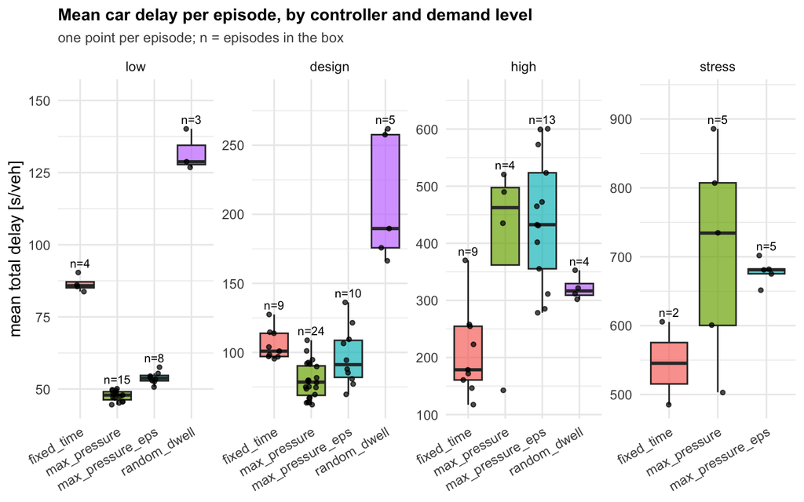

```r
ep_plot <- ep %>% mutate(demand_level = factor(demand_level, levels = lvl))
box_n <- ep_plot %>% group_by(demand_level, controller) %>%
  summarise(n = n(), y = max(mean_total_delay_s), .groups = "drop")
ggplot(ep_plot, aes(controller, mean_total_delay_s, fill = controller)) +
  geom_boxplot(alpha = 0.7, outlier.shape = NA) +
  geom_jitter(width = 0.15, size = 1.2, alpha = 0.7) +
  geom_text(data = box_n, aes(controller, y, label = paste0("n=", n)), vjust = -0.6, size = 3) +
  scale_y_continuous(expand = expansion(mult = c(0.05, 0.18))) +
  facet_wrap(~ demand_level, scales = "free", ncol = 4, drop = TRUE) +
  labs(title = "Mean car delay per episode, by controller and demand level",
       subtitle = "one point per episode; n = episodes in the box",
       x = NULL, y = "mean total delay [s/veh]") +
  theme(legend.position = "none", axis.text.x = element_text(angle = 30, hjust = 1))
```

```r
ep %>% group_by(demand_level, controller) %>%
  summarise(episodes = n(), mean_delay_s = mean(mean_total_delay_s),
            ci_half = ifelse(n() > 1, qt(0.975, n() - 1) * sd(mean_total_delay_s) / sqrt(n()), NA),
            .groups = "drop") %>%
  mutate(across(c(mean_delay_s, ci_half), ~ round(.x, 1))) %>%
  arrange(factor(demand_level, levels = lvl), controller) %>%
  kable(caption = "Mean delay by (demand level, controller) with a 95% t-interval half-width over episodes")
```

Mean delay by (demand level, controller) with a 95% t-interval half-width over episodes

| demand_level | controller | episodes | mean_delay_s | ci_half |
| --- | --- | --- | --- | --- |
| low | fixed_time | 4 | 86.4 | 4.5 |
| low | max_pressure | 15 | 47.7 | 1.0 |
| low | max_pressure_eps | 8 | 53.9 | 1.7 |
| low | random_dwell | 3 | 131.9 | 17.9 |
| design | fixed_time | 9 | 105.4 | 8.4 |
| design | max_pressure | 24 | 79.3 | 5.4 |
| design | max_pressure_eps | 10 | 96.9 | 15.1 |
| design | random_dwell | 5 | 210.3 | 57.1 |
| high | fixed_time | 9 | 209.0 | 59.3 |
| high | max_pressure | 4 | 397.0 | 275.6 |
| high | max_pressure_eps | 13 | 440.7 | 68.2 |
| high | random_dwell | 4 | 322.0 | 35.1 |
| stress | fixed_time | 2 | 545.4 | 762.9 |
| stress | max_pressure | 5 | 706.2 | 192.1 |
| stress | max_pressure_eps | 5 | 678.4 | 22.6 |

## 3.4 Fairness: delay by entry node

A signal controller can be efficient on average and still starve one arm of the grid. The entry node (`origin` in `vehicles.csv`: N0, N1, E0, … are the boundary nodes of the four sides) is a natural *protected group* for this check. The bar is the mean over episodes of the per-episode mean car delay from that origin; the whisker is the 95% t-interval over episodes.

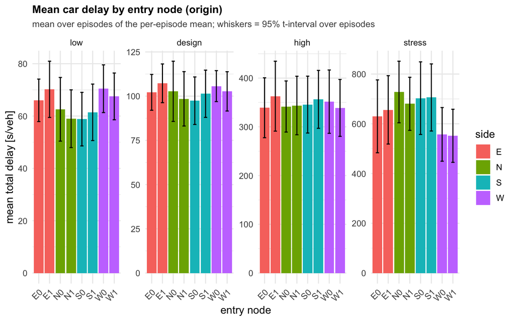

```r
fair_ep <- cars %>%
  group_by(episode_id, demand_level, demand_asym, origin) %>%
  summarise(mean_delay = mean(total_delay_s, na.rm = TRUE), cars = n(), .groups = "drop") %>%
  mutate(side = substr(origin, 1, 1))
fair <- fair_ep %>%
  group_by(demand_level, origin, side) %>%
  summarise(episodes = n(), mean_delay_s = mean(mean_delay),
            ci_half = ifelse(n() > 1, qt(0.975, n() - 1) * sd(mean_delay) / sqrt(n()), 0), .groups = "drop")
ggplot(fair, aes(origin, mean_delay_s, fill = side)) +
  geom_col() +
  geom_errorbar(aes(ymin = mean_delay_s - ci_half, ymax = mean_delay_s + ci_half), width = 0.3) +
  facet_wrap(~ demand_level, scales = "free_y", ncol = 4) +
  labs(title = "Mean car delay by entry node (origin)",
       subtitle = "mean over episodes of the per-episode mean; whiskers = 95% t-interval over episodes",
       x = "entry node", y = "mean total delay [s/veh]", fill = "side") +
  theme(axis.text.x = element_text(angle = 45, hjust = 1))
```

```r
fair_ratio <- fair %>% group_by(demand_level) %>%
  summarise(worst_origin = origin[which.max(mean_delay_s)], best_origin = origin[which.min(mean_delay_s)],
            worst_over_best = round(max(mean_delay_s) / min(mean_delay_s), 2), .groups = "drop")
kable(fair_ratio, caption = "Largest / smallest mean delay over origins, per demand level")
```

Largest / smallest mean delay over origins, per demand level

| demand_level | worst_origin | best_origin | worst_over_best |
| --- | --- | --- | --- |
| low | W0 | S0 | 1.20 |
| design | E1 | S0 | 1.10 |
| high | E1 | W1 | 1.07 |
| stress | N0 | W1 | 1.32 |

```r
fair_ep %>% group_by(demand_asym, side) %>%
  summarise(episodes = n_distinct(episode_id), mean_delay_s = round(mean(mean_delay), 1), .groups = "drop") %>%
  pivot_wider(names_from = side, values_from = mean_delay_s) %>%
  kable(caption = "Mean delay by side of entry (N/E/S/W) and demand asymmetry")
```

Mean delay by side of entry (N/E/S/W) and demand asymmetry

| demand_asym | episodes | E | N | S | W |
| --- | --- | --- | --- | --- | --- |
| ns_heavy | 60 | 208.4 | 220.3 | 219.2 | 202.6 |
| sym | 60 | 213.5 | 202.7 | 206.7 | 198.8 |

Half of the episodes use the `ns_heavy` asymmetry (north and south entries spawn more cars), so a higher delay on the N/S arms is expected there; the ratio of the worst to the best origin is the number to watch when controllers are compared later.

## 3.5 Queue over time at the four junctions of one episode

One design-demand episode driven by `max_pressure` with ambulances is picked (the first such episode in the table). `q_total` is the number of queued vehicles (v < 2 m/s) on the four approaches of a junction, logged every second. The shaded bands are the warm-up and the cool-down.

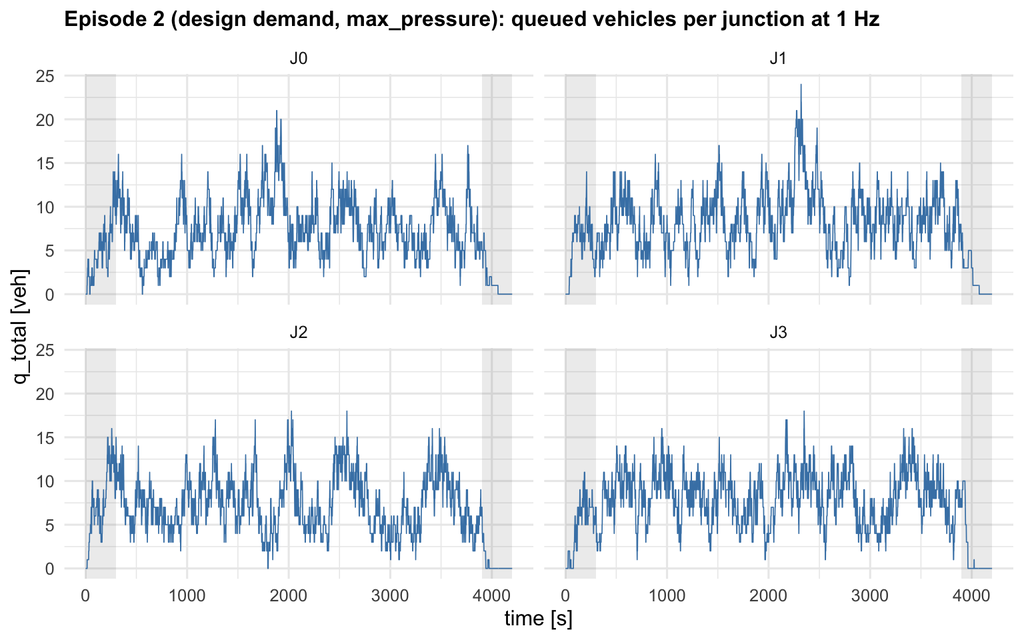

```r
pick <- ep %>% filter(demand_level == "design", controller == "max_pressure", ev_rate == "default") %>%
  arrange(episode_id)
ep_id <- if (nrow(pick) > 0) pick$episode_id[1] else ep$episode_id[1]
ep_info <- ep %>% filter(episode_id == ep_id)
jz %>% filter(episode_id == ep_id) %>%
  mutate(junction = paste0("J", junction_id)) %>%
  ggplot(aes(t, q_total)) +
  annotate("rect", xmin = 0, xmax = cfg$warmup_s, ymin = -Inf, ymax = Inf, alpha = 0.12, fill = "grey40") +
  annotate("rect", xmin = cfg$warmup_s + cfg$main_s, xmax = cfg$warmup_s + cfg$main_s + cfg$cooldown_s,
           ymin = -Inf, ymax = Inf, alpha = 0.12, fill = "grey40") +
  geom_line(colour = "steelblue", linewidth = 0.3) +
  facet_wrap(~ junction, ncol = 2) +
  labs(title = sprintf("Episode %d (%s demand, %s): queued vehicles per junction at 1 Hz",
                       ep_id, ep_info$demand_level, ep_info$controller),
       x = "time [s]", y = "q_total [veh]")
```

## 3.6 Label balance of `y_mp_action`

The imitation label is the approach (0 N, 1 E, 2 S, 3 W) that the priority-aware max-pressure teacher would give green to. Because the label is recomputed from every row regardless of which controller drove the episode, the classes are roughly balanced; an excess of N and S reflects the `ns_heavy` demand asymmetry in half of the episodes.

```r
lab <- main %>% mutate(y = factor(y_mp_action, levels = 0:3, labels = c("0 (N)", "1 (E)", "2 (S)", "3 (W)")))
balance <- lab %>% count(y) %>% mutate(share = round(n / sum(n), 3))
kable(balance, caption = "Label balance of y_mp_action on main-period rows")
```

Label balance of y_mp_action on main-period rows

| y | n | share |
| --- | --- | --- |
| 0 (N) | 69485 | 0.274 |
| 1 (E) | 56883 | 0.225 |
| 2 (S) | 70330 | 0.278 |
| 3 (W) | 56577 | 0.223 |

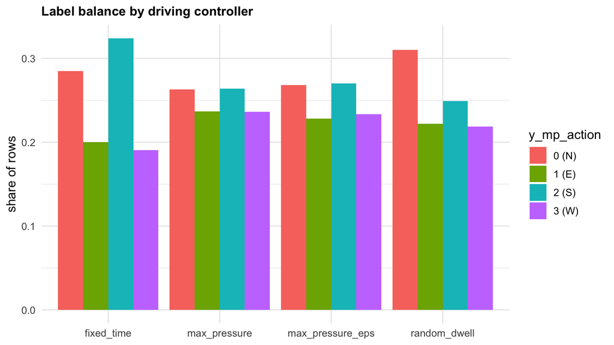

```r
ggplot(lab %>% count(controller, y) %>% group_by(controller) %>% mutate(share = n / sum(n)),
       aes(controller, share, fill = y)) +
  geom_col(position = "dodge") +
  labs(title = "Label balance by driving controller", x = NULL, y = "share of rows", fill = "y_mp_action")
```

```r
# how often does the label disagree with the current phase (a "switch")?
switch_share <- mean(main$y_mp_action != main$phase)
cat("Share of rows where the teacher wants a switch:", round(switch_share, 3), "\n")
```

```
## Share of rows where the teacher wants a switch: 0.61
```

## 3.7 Hidden driver aggressiveness `alpha` against delay

Every vehicle has a latent aggressiveness `alpha ~ Beta(2, 2)` that scales its desired speed, acceleration and headway. It is in `vehicles.csv` but not observable by a controller. Does it matter for the vehicle’s delay? The scatter uses a log y-axis, so it applies the same rule as above (finished trips with delay >= 1 s); the table and the correlation use *all* finished trips, including the ones the log axis cannot show.

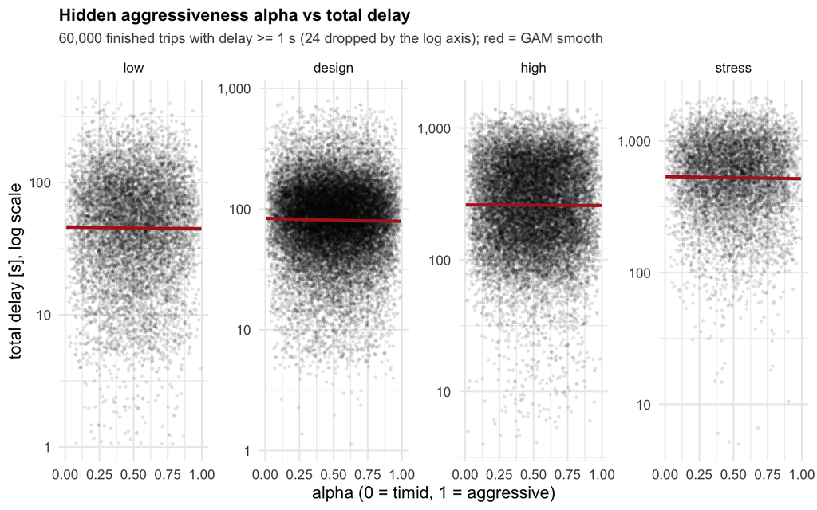

```r
alpha_all  <- cars %>% filter(completed)
alpha_pool <- alpha_all %>% filter(total_delay_s >= delay_min)
n_alpha <- min(60000, nrow(alpha_pool))
alpha_plot <- alpha_pool %>% slice_sample(n = n_alpha)
ggplot(alpha_plot, aes(alpha, total_delay_s)) +
  geom_point(alpha = 0.08, size = 0.5) +
  geom_smooth(method = "gam", formula = y ~ s(x, bs = "cs"), colour = "firebrick") +
  scale_y_log10(labels = label_comma()) +
  facet_wrap(~ demand_level, ncol = 4, scales = "free_y") +
  labs(title = "Hidden aggressiveness alpha vs total delay",
       subtitle = sprintf("%s finished trips with delay >= %d s (%d dropped by the log axis); red = GAM smooth",
                          format(n_alpha, big.mark = ","), delay_min, nrow(alpha_all) - nrow(alpha_pool)),
       x = "alpha (0 = timid, 1 = aggressive)", y = "total delay [s], log scale")
```

```r
alpha_all %>%
  mutate(alpha_bin = cut(alpha, breaks = seq(0, 1, 0.2), include.lowest = TRUE)) %>%
  group_by(alpha_bin) %>%
  summarise(vehicles = n(), mean_delay_s = round(mean(total_delay_s), 1),
            mean_free_flow_s = round(mean(free_flow_time_s), 1), .groups = "drop") %>%
  kable(caption = "Mean delay by alpha bin (all finished trips)")
```

Mean delay by alpha bin (all finished trips)

| alpha_bin | vehicles | mean_delay_s | mean_free_flow_s |
| --- | --- | --- | --- |
| [0,0.2] | 31801 | 240.2 | 42.6 |
| (0.2,0.4] | 76045 | 239.3 | 41.5 |
| (0.4,0.6] | 91182 | 233.6 | 40.0 |
| (0.6,0.8] | 76585 | 234.9 | 38.7 |
| (0.8,1] | 31955 | 235.1 | 37.8 |

```r
rho_alpha <- cor(alpha_all$alpha, alpha_all$total_delay_s, method = "spearman")
cat("Spearman correlation alpha vs delay (all finished trips):", round(rho_alpha, 3), "\n")
```

```
## Spearman correlation alpha vs delay (all finished trips): -0.013
```

The dependence is weak (Spearman rho = -0.013): in a queue everybody waits for the signal, so delay is dominated by the demand level and the controller rather than by the driver. This is reassuring for the project, because a controller cannot see `alpha`.

## 3.8 Ambulance versus car delay

In the episodes with `ev_rate == "default"` (84 of 120), ambulances (faster, more aggressive vehicles drawn from their own random stream) enter the grid at 4 per hour per entry node. In this version they are subject to the same signals as cars: the controllers that drove the episodes do not give them priority, so their delay is of the same order as a car’s, and only their shorter headway and higher desired speed make a difference. The teacher label `y_mp_action` encodes what a priority-aware rule *would* have requested; whether that reduces ambulance delay is a closed-loop question for the project, not something this table can show. The boxplot applies the same plotting rule as the other delay figures (delay >= 1 s on a log axis); the table uses all vehicles.

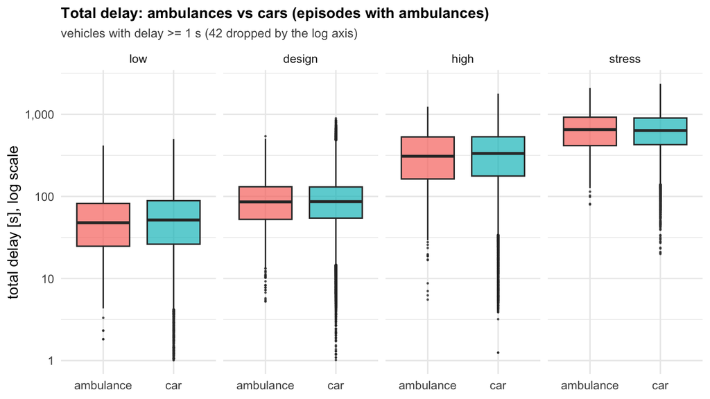

```r
ev_eps <- ep$episode_id[ep$ev_rate == "default"]
vtype <- vh %>% filter(!is_warmup, episode_id %in% ev_eps) %>%
  left_join(ep %>% select(episode_id, demand_level), by = "episode_id") %>%
  mutate(demand_level = factor(demand_level, levels = lvl))
ev_dropped <- sum(vtype$total_delay_s < delay_min, na.rm = TRUE)
ggplot(vtype %>% filter(total_delay_s >= delay_min), aes(vehicle_type, total_delay_s, fill = vehicle_type)) +
  geom_boxplot(outlier.size = 0.3, alpha = 0.7) +
  scale_y_log10(labels = label_comma()) +
  facet_wrap(~ demand_level, ncol = 4) +
  labs(title = "Total delay: ambulances vs cars (episodes with ambulances)",
       subtitle = sprintf("vehicles with delay >= %d s (%d dropped by the log axis)", delay_min, ev_dropped),
       x = NULL, y = "total delay [s], log scale") +
  theme(legend.position = "none")
```

```r
vtype %>% group_by(demand_level, vehicle_type) %>%
  summarise(vehicles = n(), mean_delay_s = round(mean(total_delay_s, na.rm = TRUE), 1),
            median_delay_s = round(median(total_delay_s, na.rm = TRUE), 1),
            mean_stops = round(mean(n_stops), 2), .groups = "drop") %>%
  kable(caption = "Ambulance vs car delay by demand level (all vehicles of the ambulance episodes)")
```

Ambulance vs car delay by demand level (all vehicles of the ambulance episodes)

| demand_level | vehicle_type | vehicles | mean_delay_s | median_delay_s | mean_stops |
| --- | --- | --- | --- | --- | --- |
| low | ambulance | 635 | 62.8 | 47.8 | 1.33 |
| low | car | 30978 | 66.2 | 51.5 | 1.33 |
| design | ambulance | 1143 | 103.6 | 85.8 | 2.15 |
| design | car | 95685 | 104.9 | 86.5 | 2.13 |
| high | ambulance | 589 | 367.1 | 305.7 | 5.89 |
| high | car | 71093 | 381.0 | 333.6 | 6.24 |
| stress | ambulance | 251 | 698.5 | 651.3 | 8.79 |
| stress | car | 33932 | 700.5 | 635.7 | 8.47 |

## 3.9 Per-episode KPI table

```r
kpi_cols <- c("episode_id", "demand_level", "controller", "split", "ev_rate", "throughput_vph",
              "mean_total_delay_s", "p90_total_delay_s", "max_queue_veh", "switches_per_min",
              "n_red_commits", "gridlock", "n_ambulances", "ev_mean_delay_s", "n_invariant_violations")
ep %>% select(all_of(kpi_cols)) %>% arrange(episode_id)
```

| episode_id | demand_level | controller | split | ev_rate | throughput_vph | mean_total_delay_s | p90_total_delay_s | max_queue_veh | switches_per_min | n_red_commits | gridlock | n_ambulances | ev_mean_delay_s | n_invariant_violations |
| --- | --- | --- | --- | --- | --- | --- | --- | --- | --- | --- | --- | --- | --- | --- |
| 0 | design | fixed_time | train | 0 | 2408 | 98.269 | 154.763 | 34 | 2.5000 | 258 | FALSE | 0 | NA | 0 |
| 1 | low | max_pressure | train | 0 | 1593 | 49.589 | 102.490 | 20 | 3.5250 | 262 | FALSE | 0 | NA | 0 |
| 2 | design | max_pressure | train | default | 2433 | 63.833 | 111.421 | 24 | 4.2042 | 651 | FALSE | 28 | 72.461 | 0 |
| 3 | low | max_pressure | train | 0 | 1583 | 46.868 | 96.433 | 12 | 3.4250 | 264 | FALSE | 0 | NA | 0 |
| 4 | stress | max_pressure | test_ood | default | 3160 | 600.357 | 977.175 | 133 | 4.4333 | 1288 | FALSE | 40 | 599.890 | 0 |
| 5 | low | max_pressure_eps | train | 0 | 1490 | 52.596 | 96.178 | 13 | 4.3958 | 390 | FALSE | 0 | NA | 0 |
| 6 | stress | max_pressure | test_ood | default | 3194 | 807.393 | 1410.000 | 137 | 4.4458 | 1278 | FALSE | 39 | 823.498 | 0 |
| 7 | low | max_pressure | train | default | 1426 | 48.386 | 96.300 | 11 | 3.3208 | 192 | FALSE | 36 | 40.380 | 0 |
| 8 | high | max_pressure_eps | train | 0 | 3070 | 278.434 | 478.443 | 126 | 4.8208 | 1610 | FALSE | 0 | NA | 0 |
| 9 | design | fixed_time | train | 0 | 2442 | 95.444 | 151.635 | 30 | 2.5000 | 280 | FALSE | 0 | NA | 0 |

[output cut: 110 more lines]

# 4 A simple feasibility model

**Question.** Can the teacher’s request `y_mp_action` be recovered from the feature row alone? If a shallow model manages it, learning a controller from this table is feasible.

**Protocol.** Features are the observable columns of the dictionary (`twin_observable == TRUE`) minus the noisy sensor copies `obs_q_*`: the signal state, the per-approach counts, the downstream and neighbour columns and the ambulance channel. Keys, period flags, the controller’s own actions and the labels are excluded. The split is **by episode** (`split` column), never by row, because consecutive rows five seconds apart are near-duplicates. The model is a depth-5 `rpart` tree, fitted on the `train` episodes and scored on the `test` episodes.

```r
observable <- dd$column[dd$table == "signal_ticks" & dd$twin_observable]
sensor     <- dd$column[dd$table == "signal_ticks" & dd$namespace == "sensor"]
features   <- setdiff(intersect(observable, names(main)), sensor)
cat(length(features), "features:\n"); print(features)
```

```
## 63 features:
```

```
##  [1] "phase"                 "time_in_phase_s"       "max_green_remaining_s"
##  [4] "q_N"                   "n_N"                   "q_N_l0"
##  [7] "q_N_l1"                "arr_N_30s"             "q_E"
## [10] "n_E"                   "q_E_l0"                "q_E_l1"
## [13] "arr_E_30s"             "q_S"                   "n_S"
## [16] "q_S_l0"                "q_S_l1"                "arr_S_30s"
## [19] "q_W"                   "n_W"                   "q_W_l0"
## [22] "q_W_l1"                "arr_W_30s"             "down_n_N"
## [25] "down_occ_N"            "down_blocked_N"        "down_n_E"
## [28] "down_occ_E"            "down_blocked_E"        "down_n_S"
## [31] "down_occ_S"            "down_blocked_S"        "down_n_W"
## [34] "down_occ_W"            "down_blocked_W"        "nb_N_exists"
## [37] "nb_N_phase"            "nb_N_green_toward_me"  "nb_E_exists"
## [40] "nb_E_phase"            "nb_E_green_toward_me"  "nb_S_exists"
## [43] "nb_S_phase"            "nb_S_green_toward_me"  "nb_W_exists"
## [46] "nb_W_phase"            "nb_W_green_toward_me"  "ev_present_N"
## [49] "ev_dist_N"             "ev_eta_N"              "ev_q_ahead_N"
## [52] "ev_present_E"          "ev_dist_E"             "ev_eta_E"
## [55] "ev_q_ahead_E"          "ev_present_S"          "ev_dist_S"
## [58] "ev_eta_S"              "ev_q_ahead_S"          "ev_present_W"
## [61] "ev_dist_W"             "ev_eta_W"              "ev_q_ahead_W"
```

```r
train <- main %>% filter(split == "train")
test  <- main %>% filter(split == "test")
ood   <- main %>% filter(split == "test_ood")
if (nrow(test) == 0) {            # a small development release may have no test episodes
  cat("No 'test' episodes in this release: the 'val' episodes serve as the hold-out set.\n")
  test <- main %>% filter(split == "val")
}
cat("train rows:", nrow(train), " test rows:", nrow(test), " test_ood rows:", nrow(ood), "\n")
```

```
## train rows: 167542  test rows: 31390  test_ood rows: 24314
```

```r
set.seed(42)
t0 <- Sys.time()
formula_raw <- as.formula(paste("factor(y_mp_action) ~", paste(features, collapse = " + ")))
fit_raw <- rpart(formula_raw, data = train, method = "class",
                 control = rpart.control(maxdepth = 5, cp = 0.001, minbucket = 50))
cat("Fitted in", round(as.numeric(difftime(Sys.time(), t0, units = "secs")), 1), "s\n")
```

```
## Fitted in 8.6 s
```

```r
pred_raw <- predict(fit_raw, test, type = "class")
acc_raw  <- mean(pred_raw == test$y_mp_action)
cat(sprintf("Test accuracy (raw features, depth 5): %.3f  (chance = 0.25, majority class = %.3f)\n",
            acc_raw, max(table(test$y_mp_action)) / nrow(test)))
```

```
## Test accuracy (raw features, depth 5): 0.466  (chance = 0.25, majority class = 0.291)
```

```r
conf_raw <- table(predicted = pred_raw, actual = test$y_mp_action)
kable(conf_raw, caption = "Confusion table on test episodes (rows = predicted, columns = actual)")
```

Confusion table on test episodes (rows = predicted, columns = actual)

|  | 0 | 1 | 2 | 3 |
| --- | --- | --- | --- | --- |
| 0 | 3204 | 834 | 442 | 849 |
| 1 | 2039 | 3949 | 2433 | 2847 |
| 2 | 3247 | 1976 | 6148 | 1871 |
| 3 | 61 | 71 | 105 | 1314 |

```r
print(fit_raw)
```

```
## n= 167542
##
## node), split, n, loss, yval, (yprob)
##       * denotes terminal node
##
##  1) root 167542 121490 0 (0.274868391 0.227328073 0.271090234 0.226713302)
##    2) ev_present_W< 0.5 157873 112664 0 (0.286363089 0.237095640 0.283835741 0.192705529)
##      4) ev_present_E>=0.5 7747   1388 1 (0.083128953 0.820833871 0.079643733 0.016393443) *
##      5) ev_present_E< 0.5 150126 105561 0 (0.296850645 0.206972810 0.294372727 0.201803818)
##       10) ev_present_N>=0.5 6553    675 0 (0.896993743 0.023653289 0.058904319 0.020448649) *
##       11) ev_present_N< 0.5 143573  99766 2 (0.269458742 0.215339932 0.305120043 0.210081283)
##         22) n_S< 5.5 79531  54769 0 (0.311350291 0.249324163 0.192553847 0.246771699)
##           44) n_N>=4.5 26132  11914 0 (0.544083882 0.177636614 0.075042094 0.203237410) *
##           45) n_N< 4.5 53399  38212 1 (0.197456881 0.284406075 0.250060863 0.268076181) *
##         23) n_S>=5.5 64042  35549 2 (0.217435433 0.173136379 0.444911152 0.164517036) *
##    3) ev_present_W>=0.5 9669   2108 3 (0.087185852 0.067845692 0.062984797 0.781983659)
##      6) ev_present_N>=0.5 1156    561 0 (0.514705882 0.058823529 0.030276817 0.396193772)
##       12) ev_eta_W>=5.325 731    237 0 (0.675786594 0.082079343 0.043775650 0.198358413) *
##       13) ev_eta_W< 5.325 425    112 3 (0.237647059 0.018823529 0.007058824 0.736470588) *
##      7) ev_present_N< 0.5 8513   1410 3 (0.029131916 0.069070833 0.067426289 0.834370962)
##       14) ev_present_E>=0.5 942    502 1 (0.002123142 0.467091295 0.072186837 0.458598726)
##         28) ev_dist_E< 14.975 343     50 1 (0.000000000 0.854227405 0.008746356 0.137026239) *
##         29) ev_dist_E>=14.975 599    214 3 (0.003338898 0.245409015 0.108514190 0.642737896) *
##       15) ev_present_E< 0.5 7571    900 3 (0.032492405 0.019548276 0.066833972 0.881125347) *
```

Rather than describing the tree by hand, a helper reads the fitted object: which condition is at the root, which variables appear at each depth, and how the accuracy differs between rows with and without an ambulance in sight.

```r
tree_story <- function(fit) {
  fr    <- fit$frame
  node  <- as.integer(rownames(fr))        # rpart node numbers: children of k are 2k and 2k+1
  depth <- floor(log2(node))
  lab   <- labels(fit)                     # the condition that leads INTO each node
  is_split <- fr$var != "<leaf>"
  vars_by_depth <- tapply(as.character(fr$var[is_split]), depth[is_split],
                          function(v) paste(unique(v), collapse = ", "))
  list(root = lab[node == 2],              # condition of the left child = the root split
       by_depth = data.frame(depth = as.integer(names(vars_by_depth)) + 1,
                             split_variables = unname(vars_by_depth)),
       n_leaves = sum(!is_split),
       vars_used = unique(as.character(fr$var[is_split])))
}
ev_in_sight <- function(d) d$ev_present_N | d$ev_present_E | d$ev_present_S | d$ev_present_W
acc_by_ev <- function(pred, d) {
  ev <- ev_in_sight(d)
  data.frame(rows = c("ambulance in sight", "no ambulance"),
             n = c(sum(ev), sum(!ev)),
             share_of_rows = round(c(mean(ev), mean(!ev)), 3),
             accuracy = round(c(mean(pred[ev] == d$y_mp_action[ev]), mean(pred[!ev] == d$y_mp_action[!ev])), 3))
}
story_raw <- tree_story(fit_raw)
cat("Root split:", story_raw$root, "\n")
```

```
## Root split: ev_present_W< 0.5
```

```r
kable(story_raw$by_depth, caption = "Variables used at each depth of the raw-feature tree")
```

Variables used at each depth of the raw-feature tree

| depth | split_variables |
| --- | --- |
| 1 | ev_present_W |
| 2 | ev_present_E, ev_present_N |
| 3 | ev_present_N, ev_eta_W, ev_present_E |
| 4 | n_S, ev_dist_E |
| 5 | n_N |

```r
kable(acc_by_ev(pred_raw, test), caption = "Raw-feature tree: test accuracy with and without an ambulance in sight")
```

Raw-feature tree: test accuracy with and without an ambulance in sight

| rows | n | share_of_rows | accuracy |
| --- | --- | --- | --- |
| ambulance in sight | 5885 | 0.187 | 0.800 |
| no ambulance | 25505 | 0.813 | 0.388 |

```r
share_no_ev_main <- mean(!ev_in_sight(main))
cat(sprintf("Share of main-period rows with no ambulance in sight: %.3f\n", share_no_ev_main))
```

```
## Share of main-period rows with no ambulance in sight: 0.798
```

**Reading (generated from the fitted tree).** The root split is `ev_present_W< 0.5`; the variables used, from the top down, are ev_present_W, ev_present_E, ev_present_N, n_S, n_N, ev_eta_W, ev_dist_E (10 leaves). The ambulance channel appears among the split variables: when an ambulance is close to a stop line the teacher asks for that approach, which a single threshold can express. Rows without an ambulance in sight are 79.8% of the main-period rows; on those the label is the plain max-pressure rule, which compares *differences* of counts (`n_a - mean(down_n)` across approaches, with hysteresis against the current phase). A depth-5 tree over raw counts cannot express those comparisons, so its accuracy on the no-ambulance rows stays at 0.388.

```r
imp <- sort(fit_raw$variable.importance, decreasing = TRUE)[1:min(10, length(fit_raw$variable.importance))]
kable(data.frame(variable = names(imp), importance = round(imp, 0), row.names = NULL),
      caption = "Top-10 variables by rpart importance (raw features)")
```

Top-10 variables by rpart importance (raw features)

| variable | importance |
| --- | --- |
| ev_eta_W | 4361 |
| ev_dist_W | 4351 |
| ev_q_ahead_W | 4326 |
| ev_present_W | 4231 |
| ev_dist_E | 4162 |
| ev_eta_E | 4148 |
| n_N | 4124 |
| ev_q_ahead_E | 4111 |
| ev_present_E | 4024 |
| ev_dist_N | 3740 |

## 4.1 The same tree with the pressures computed from the row

The max-pressure rule is a function of the row, so we can *compute* the pressures from the observable columns (this is exactly what the twin will do at run time) and offer them to the tree:

```r
dirs <- c("N", "E", "S", "W")
add_pressure <- function(d) {
  # pressure_a = n_a - mean(down_n over a's unblocked exits), as in the controller
  for (a in dirs) {
    total <- 0; count <- 0
    for (o in setdiff(dirs, a)) {
      ok    <- !d[[paste0("down_blocked_", o)]]
      total <- total + ifelse(ok, d[[paste0("down_n_", o)]], 0)
      count <- count + ok
    }
    # as.numeric(): keep one storage type in every split, which rpart::predict insists on
    d[[paste0("pressure_", a)]] <- as.numeric(ifelse(count > 0, d[[paste0("n_", a)]] - total / pmax(count, 1), -1e9))
  }
  P <- as.matrix(d[paste0("pressure_", dirs)])
  d$pressure_cur  <- as.numeric(P[cbind(seq_len(nrow(d)), d$phase + 1)])   # pressure of the current green
  d$pressure_best <- as.numeric(apply(P, 1, max))
  d$best_dir      <- as.numeric(apply(P, 1, which.max) - 1)
  d$pressure_gain <- d$pressure_best - d$pressure_cur
  d
}
train_p <- add_pressure(train); test_p <- add_pressure(test); ood_p <- add_pressure(ood)
features_p <- c(features, grep("^pressure_|^best_dir$", names(train_p), value = TRUE))

set.seed(42)
fit_p <- rpart(as.formula(paste("factor(y_mp_action) ~", paste(features_p, collapse = " + "))),
               data = train_p, method = "class",
               control = rpart.control(maxdepth = 5, cp = 0.001, minbucket = 50))
pred_p <- predict(fit_p, test_p, type = "class")
acc_p  <- mean(pred_p == test_p$y_mp_action)
acc_p_ood <- mean(predict(fit_p, ood_p, type = "class") == ood_p$y_mp_action)
cat(sprintf("Test accuracy (with pressures, depth 5): %.3f;  on stress episodes (test_ood): %.3f\n", acc_p, acc_p_ood))
```

```
## Test accuracy (with pressures, depth 5): 0.815;  on stress episodes (test_ood): 0.752
```

```r
kable(table(predicted = pred_p, actual = test_p$y_mp_action),
      caption = "Confusion table on test episodes, tree with pressure features")
```

Confusion table on test episodes, tree with pressure features

|  | 0 | 1 | 2 | 3 |
| --- | --- | --- | --- | --- |
| 0 | 7562 | 1177 | 969 | 1089 |
| 1 | 342 | 5383 | 367 | 288 |
| 2 | 305 | 126 | 7515 | 388 |
| 3 | 342 | 144 | 277 | 5116 |

```r
print(fit_p)
```

```
## n= 167542
##
## node), split, n, loss, yval, (yprob)
##       * denotes terminal node
##
##  1) root 167542 121490 0 (2.748684e-01 2.273281e-01 2.710902e-01 2.267133e-01)
##    2) best_dir< 0.5 48182  13945 0 (7.105766e-01 8.849778e-02 1.030053e-01 9.792039e-02)
##      4) pressure_gain>=2 28425   3760 0 (8.677221e-01 4.503078e-02 3.908531e-02 4.816183e-02)
##        8) ev_present_W< 0.5 26972   2629 0 (9.025285e-01 4.526917e-02 3.907756e-02 1.312472e-02)
##         16) ev_present_E< 0.5 25804   1701 0 (9.340800e-01 1.337002e-02 3.883119e-02 1.371880e-02) *
##         17) ev_present_E>=0.5 1168    292 1 (2.054795e-01 7.500000e-01 4.452055e-02 0.000000e+00) *
##        9) ev_present_W>=0.5 1453    438 3 (2.216105e-01 4.060564e-02 3.922918e-02 6.985547e-01) *
##      5) pressure_gain< 2 19757  10185 0 (4.844865e-01 1.510351e-01 1.949689e-01 1.695095e-01)
##       10) phase< 0.5 10397   1190 0 (8.855439e-01 3.770318e-02 3.558719e-02 4.116572e-02)
##         20) ev_present_E< 0.5 9913    730 0 (9.263593e-01 0.000000e+00 3.399576e-02 3.964491e-02)
##           40) ev_present_W< 0.5 9432    321 0 (9.659669e-01 0.000000e+00 3.403308e-02 0.000000e+00) *
##           41) ev_present_W>=0.5 481     88 3 (1.496881e-01 0.000000e+00 3.326403e-02 8.170478e-01) *
##         21) ev_present_E>=0.5 484     92 1 (4.958678e-02 8.099174e-01 6.818182e-02 7.231405e-02) *
##       11) phase>=0.5 9360   5878 2 (3.899573e-02 2.769231e-01 3.720085e-01 3.120726e-01)
##         22) phase< 2.5 6381   2952 2 (3.698480e-02 3.942956e-01 5.373766e-01 3.134305e-02)
##           44) phase< 1.5 2690    256 1 (3.940520e-02 9.048327e-01 2.193309e-02 3.382900e-02) *
##           45) phase>=1.5 3691    321 2 (3.522081e-02 2.221620e-02 9.130317e-01 2.953129e-02) *
##         23) phase>=2.5 2979    258 3 (4.330312e-02 2.551192e-02 1.779121e-02 9.133938e-01) *
##    3) best_dir>=0.5 119360  78904 2 (9.898626e-02 2.833696e-01 3.389410e-01 2.787031e-01)
##      6) best_dir< 2.5 83682  46725 2 (1.008102e-01 3.663751e-01 4.416362e-01 9.117851e-02)
##       12) best_dir< 1.5 38064  11486 1 (1.077659e-01 6.982451e-01 9.964796e-02 9.434111e-02)
##         24) pressure_gain>=2 22795   3284 1 (5.080061e-02 8.559333e-01 4.641369e-02 4.685238e-02)
##           48) ev_present_W< 0.5 21642   2340 1 (4.967193e-02 8.918769e-01 4.722299e-02 1.122817e-02) *
##           49) ev_present_W>=0.5 1153    328 3 (7.198612e-02 1.812663e-01 3.122290e-02 7.155247e-01) *
##         25) pressure_gain< 2 15269   8202 1 (1.928090e-01 4.628332e-01 1.791211e-01 1.652368e-01)
##           50) pressure_gain< 5.551115e-17 8059   1321 1 (3.573644e-02 8.360839e-01 6.737809e-02 6.080159e-02) *
##           51) pressure_gain>=5.551115e-17 7210   4554 0 (3.683773e-01 4.563107e-02 3.040222e-01 2.819695e-01) *
##       13) best_dir>=1.5 45618  12454 2 (9.500636e-02 8.946030e-02 7.269937e-01 8.853961e-02)
##         26) pressure_gain< 2 19369   9896 2 (1.869998e-01 1.627859e-01 4.890805e-01 1.611338e-01)
##           52) pressure_gain>=2.775558e-17 9006   5744 0 (3.622030e-01 3.102376e-01 5.574062e-02 2.718188e-01) *
##           53) pressure_gain< 2.775558e-17 10363   1392 2 (3.473898e-02 3.464248e-02 8.656760e-01 6.494258e-02) *
##         27) pressure_gain>=2 26249   2558 2 (2.712484e-02 3.535373e-02 9.025487e-01 3.497276e-02)
##           54) ev_present_E>=0.5 1312    386 1 (4.573171e-02 7.057927e-01 1.935976e-01 5.487805e-02) *
##           55) ev_present_E< 0.5 24937   1500 2 (2.614589e-02 8.020211e-05 9.398484e-01 3.392549e-02) *
##      7) best_dir>=2.5 35678  10042 3 (9.470822e-02 8.868210e-02 9.807164e-02 7.185380e-01)
##       14) pressure_gain< 2 14111   7359 3 (1.797888e-01 1.571823e-01 1.845369e-01 4.784920e-01)
##         28) pressure_gain>=2.775558e-17 7052   4611 2 (3.241634e-01 2.790698e-01 3.461429e-01 5.062394e-02)
##           56) phase< 1.5 4467   2243 0 (4.978733e-01 4.262368e-01 2.350571e-02 5.238415e-02) *
##           57) phase>=1.5 2585    249 2 (2.398453e-02 2.475822e-02 9.036750e-01 4.758221e-02) *
##         29) pressure_gain< 2.775558e-17 7059    664 3 (3.555744e-02 3.541578e-02 2.309109e-02 9.059357e-01)
##           58) ev_present_E>=0.5 326     76 1 (7.055215e-02 7.668712e-01 7.668712e-02 8.588957e-02) *
##           59) ev_present_E< 0.5 6733    366 3 (3.386306e-02 0.000000e+00 2.049606e-02 9.456409e-01) *
##       15) pressure_gain>=2 21567   2683 3 (3.904113e-02 4.386331e-02 4.149859e-02 8.755970e-01)
##         30) ev_present_E>=0.5 1000    300 1 (6.400000e-02 7.000000e-01 6.100000e-02 1.750000e-01) *
##         31) ev_present_E< 0.5 20567   1858 3 (3.782759e-02 1.196091e-02 4.055040e-02 9.096611e-01) *
```

```r
# a compact text summary of both trees: size, splits used, accuracy
tree_summary <- function(fit, name, acc) {
  frame <- fit$frame
  data.frame(model = name, terminal_nodes = sum(frame$var == "<leaf>"),
             splits_on = paste(unique(as.character(frame$var[frame$var != "<leaf>"])), collapse = ", "),
             test_accuracy = round(acc, 3))
}
kable(bind_rows(tree_summary(fit_raw, "raw features", acc_raw),
                tree_summary(fit_p, "raw + pressures", acc_p)),
      caption = "Text summary of the two trees")
```

Text summary of the two trees

| model | terminal_nodes | splits_on | test_accuracy |
| --- | --- | --- | --- |
| raw features | 10 | ev_present_W, ev_present_E, ev_present_N, n_S, n_N, ev_eta_W, ev_dist_E | 0.466 |
| raw + pressures | 23 | best_dir, pressure_gain, ev_present_W, ev_present_E, phase | 0.815 |

```r
story_p <- tree_story(fit_p)
cat("Root split of the pressure tree:", story_p$root, "\n")
```

```
## Root split of the pressure tree: best_dir< 0.5
```

```r
kable(story_p$by_depth, caption = "Variables used at each depth of the pressure tree")
```

Variables used at each depth of the pressure tree

| depth | split_variables |
| --- | --- |
| 1 | best_dir |
| 2 | pressure_gain, best_dir |
| 3 | ev_present_W, phase, best_dir, pressure_gain |
| 4 | ev_present_E, phase, pressure_gain |
| 5 | ev_present_W, phase, pressure_gain, ev_present_E |

```r
kable(acc_by_ev(pred_p, test_p), caption = "Pressure tree: test accuracy with and without an ambulance in sight")
```

Pressure tree: test accuracy with and without an ambulance in sight

| rows | n | share_of_rows | accuracy |
| --- | --- | --- | --- |
| ambulance in sight | 5885 | 0.187 | 0.507 |
| no ambulance | 25505 | 0.813 | 0.886 |

```r
printcp(fit_p)
```

```
##
## Classification tree:
## rpart(formula = as.formula(paste("factor(y_mp_action) ~", paste(features_p,
##     collapse = " + "))), data = train_p, method = "class", control = rpart.control(maxdepth = 5,
##     cp = 0.001, minbucket = 50))
##
## Variables actually used in tree construction:
## [1] best_dir      ev_present_E  ev_present_W  phase         pressure_gain
##
## Root node error: 121490/167542 = 0.72513
##
## n= 167542
##
##           CP nsplit rel error  xerror      xstd
## 1  0.2357478      0   1.00000 1.00000 0.0015042
## 2  0.1848794      1   0.76425 0.76425 0.0016747
## 3  0.0128282      3   0.39449 0.39449 0.0015226
## 4  0.0115318      7   0.32733 0.32733 0.0014334
## 5  0.0113590     10   0.29273 0.30437 0.0013973
## 6  0.0095769     12   0.27001 0.28385 0.0013622
## 7  0.0057042     14   0.25086 0.25107 0.0013001
## 8  0.0055313     15   0.24516 0.24470 0.0012871
## 9  0.0052350     16   0.23962 0.23932 0.0012759
## 10 0.0050704     17   0.23439 0.23494 0.0012666
## 11 0.0043213     18   0.22932 0.22974 0.0012554
## 12 0.0030291     19   0.22500 0.22454 0.0012439
## 13 0.0026422     20   0.22197 0.22178 0.0012377
## 14 0.0018273     21   0.21933 0.21803 0.0012292
## 15 0.0010000     22   0.21750 0.21703 0.0012269
```

**Reading (generated from the fitted tree).** With the pressures available, the five-level tree reaches 81.5% accuracy on unseen episodes (46.6% without them). Its root split is `best_dir< 0.5` and the variables it uses are best_dir, pressure_gain, ev_present_W, ev_present_E, phase, i.e. the tree picks the computed pressure columns first. The ambulance columns are still used, for the rows where the teacher overrides the pressures. The accuracy on the stress episodes is 75.2%, lower than on the test episodes, so the rule only partly transfers to a demand level never seen in training.

```r
ev_cmp <- data.frame(tree = c("raw features", "raw + pressures"),
                     acc_ambulance_rows = c(acc_by_ev(pred_raw, test)$accuracy[1], acc_by_ev(pred_p, test_p)$accuracy[1]),
                     acc_no_ambulance_rows = c(acc_by_ev(pred_raw, test)$accuracy[2], acc_by_ev(pred_p, test_p)$accuracy[2]))
kable(ev_cmp, caption = "Test accuracy of the two trees on rows with / without an ambulance in sight")
```

Test accuracy of the two trees on rows with / without an ambulance in sight

| tree | acc_ambulance_rows | acc_no_ambulance_rows |
| --- | --- | --- |
| raw features | 0.800 | 0.388 |
| raw + pressures | 0.507 | 0.886 |

On the rows *without* an ambulance the pressure tree scores 0.886 against 0.388 for the raw tree; on the rows *with* an ambulance in sight it scores 0.507 against 0.800, so with only five levels the pressure tree spends its splits on the (far more frequent) max-pressure rows and gives up part of the ambulance rows; a model with more capacity is needed to get both. The remaining errors are the hysteresis and max-green corner cases that a depth-5 tree cannot carve out; a deeper tree or a boosted model (the plan for the final project) is expected to close part of that gap.

# 5 Results of the Python ML pipeline (if available)

The project’s Python pipeline (`traffic_twin/ml.py`) trains logistic regression, gradient boosting and a decision tree for Task A (imitation of `y_mp_action`) and ridge / gradient boosting for Task B (predicting `y_q_total_t30`). If its `results.json` is next to this report, the headline test metrics are pulled in; the section is skipped otherwise.

```r
ml_path <- params$ml_results
if (!file.exists(ml_path)) {
  cat("No `", ml_path, "` found: ML pipeline results not shown.\n\n", sep = "")
} else {
  ml <- fromJSON(ml_path, simplifyVector = FALSE)
  same_release <- isTRUE(ml$n_episodes == nrow(ep)) && isTRUE(ml$n_main_rows == nrow(main))
  cat(sprintf("`results.json`: %d episodes, %d main rows (this report: %d episodes, %d main rows) -> **%s**\n\n",
              ml$n_episodes, ml$n_main_rows, nrow(ep), nrow(main),
              if (same_release) "same release" else "DIFFERENT release: the numbers below were computed on other data"))
  task_a <- bind_rows(lapply(names(ml$task_a$models), function(m) {
    s <- ml$task_a$models[[m]]$splits
    data.frame(task = "A: y_mp_action", model = m,
               test_bal_acc = round(s$test$balanced_accuracy, 3), test_macro_f1 = round(s$test$macro_f1, 3),
               ood_bal_acc = round(s$test_ood$balanced_accuracy, 3), ood_macro_f1 = round(s$test_ood$macro_f1, 3))
  }))
  cat(kable(task_a, caption = "Task A (classification) headline metrics from results.json"), sep = "\n")
  task_b <- bind_rows(lapply(names(ml$task_b$models), function(m) {
    s <- ml$task_b$models[[m]]$splits
    data.frame(task = "B: y_q_total_t30", model = m,
               test_mae = round(s$test$mae, 2), test_r2 = round(s$test$r2, 3),
               ood_mae = round(s$test_ood$mae, 2), ood_r2 = round(s$test_ood$r2, 3))
  }))
  nb <- ml$task_b$naive_baseline
  task_b <- bind_rows(task_b, data.frame(task = "B: y_q_total_t30", model = "naive (q_total now)",
                                         test_mae = round(nb$test$mae, 2), test_r2 = round(nb$test$r2, 3),
                                         ood_mae = round(nb$test_ood$mae, 2), ood_r2 = round(nb$test_ood$r2, 3)))
  cat(kable(task_b, caption = "Task B (regression) headline metrics from results.json"), sep = "\n")
  cat("\n")
}
```

`results.json`: 120 episodes, 253275 main rows (this report: 120 episodes, 253275 main rows) -> **same release**

Task A (classification) headline metrics from results.json

| task | model | test_bal_acc | test_macro_f1 | ood_bal_acc | ood_macro_f1 |
| --- | --- | --- | --- | --- | --- |
| A: y_mp_action | logreg_truth | 0.941 | 0.940 | 0.919 | 0.918 |
| A: y_mp_action | hgb_truth | 0.949 | 0.948 | 0.887 | 0.887 |
| A: y_mp_action | tree_truth | 0.455 | 0.434 | 0.440 | 0.416 |
| A: y_mp_action | logreg_sensor | 0.719 | 0.719 | 0.778 | 0.778 |
| A: y_mp_action | hgb_sensor | 0.760 | 0.759 | 0.796 | 0.796 |
| A: y_mp_action | tree_sensor | 0.418 | 0.351 | 0.476 | 0.444 |

Task B (regression) headline metrics from results.json

| task | model | test_mae | test_r2 | ood_mae | ood_r2 |
| --- | --- | --- | --- | --- | --- |
| B: y_q_total_t30 | ridge | 3.09 | 0.983 | 4.79 | 0.954 |
| B: y_q_total_t30 | hgb | 2.56 | 0.989 | 4.22 | 0.964 |
| B: y_q_total_t30 | naive (q_total now) | 3.68 | 0.973 | 5.92 | 0.928 |

# 6 Cross-checks against the methodology

The methodology fixes several numbers that the dataset must reproduce. `config.json` holds the configuration with which every episode was generated.

```r
cat("generator_version:", cfg$generator_version, "\n")
```

```
## generator_version: traffic_twin_v1.2
```

```r
cat("measured saturation flow:", cfg$measured_sat_flow_vphpl, "veh/h/lane (expected range",
    paste(cfg$sat_flow_expected_range, collapse = "-"), ")\n")
```

```
## measured saturation flow: 1631.35 veh/h/lane (expected range 1600-1900 )
```

```r
cat("start-up lost time:", cfg$startup_lost_time_s, "s\n")
```

```
## start-up lost time: 1.285 s
```

```r
if (!is.null(cfg$capacity_vph))
  cat("capacity per approach: formula", cfg$capacity_formula_vph, "veh/h, realised", cfg$capacity_vph,
      "veh/h (realisation", cfg$capacity_realisation, ")\n")
```

```
## capacity per approach: formula 611.76 veh/h, realised 549 veh/h (realisation 0.8974 )
```

```r
lambda <- data.frame(demand_level = names(cfg$lambda_base_vph), lambda_base_vph = unlist(cfg$lambda_base_vph), row.names = NULL)
kable(lambda, caption = "Calibrated arrival rate per entry node and demand level (veh/h)")
```

Calibrated arrival rate per entry node and demand level (veh/h)

| demand_level | lambda_base_vph |
| --- | --- |
| design | 325.678 |
| high | 441.992 |
| low | 186.102 |
| stress | 535.042 |

```r
checks <- c(
  "saturation flow inside the expected range" =
    cfg$measured_sat_flow_vphpl >= cfg$sat_flow_expected_range[1] && cfg$measured_sat_flow_vphpl <= cfg$sat_flow_expected_range[2],
  "every episode stores the same measured saturation flow" = all(ep$measured_sat_flow_vphpl == cfg$measured_sat_flow_vphpl),
  "episode lambda = level lambda x jitter in [0.9, 1.1]" = all(abs(ep$lambda_base_vph /
      unlist(cfg$lambda_base_vph)[ep$demand_level] - 1) <= cfg$demand_jitter + 1e-6),
  "invariant violations are zero in every episode" = all(ep$n_invariant_violations == 0),
  "seed = seed_base + episode_id (deterministic)" = all(ep$seed == cfg$seed_base + ep$episode_id),
  "one config_hash and generator_version for all episodes" =
    length(unique(ep$config_hash)) == 1 && length(unique(ep$generator_version)) == 1,
  "episodes.csv generator_version equals config.json" = all(ep$generator_version == cfg$generator_version),
  "row counts equal the data card head line" = all(count_check$match),
  "vehicle conservation: spawned = arrived + in network + queued" =
    all(ep$n_spawned == ep$n_arrived + ep$n_in_network_end + ep$n_entry_queued_end),
  "stress episodes are all in test_ood" = all(ep$split[ep$demand_level == "stress"] == "test_ood"),
  "random_dwell episodes are train only" = all(ep$split[ep$controller == "random_dwell"] == "train")
)
kable(data.frame(check = names(checks), passed = unname(checks)), caption = "Methodology cross-checks")
```

Methodology cross-checks

| check | passed |
| --- | --- |
| saturation flow inside the expected range | TRUE |
| every episode stores the same measured saturation flow | TRUE |
| episode lambda = level lambda x jitter in [0.9, 1.1] | TRUE |
| invariant violations are zero in every episode | TRUE |
| seed = seed_base + episode_id (deterministic) | TRUE |
| one config_hash and generator_version for all episodes | TRUE |
| episodes.csv generator_version equals config.json | TRUE |
| row counts equal the data card head line | TRUE |
| vehicle conservation: spawned = arrived + in network + queued | TRUE |
| stress episodes are all in test_ood | TRUE |
| random_dwell episodes are train only | TRUE |

```r
cat("Checks passed:", sum(checks), "of", length(checks), "\n")
```

```
## Checks passed: 11 of 11
```

```r
cat("Total invariant violations over", nrow(ep), "episodes:", sum(ep$n_invariant_violations), "\n")
```

```
## Total invariant violations over 120 episodes: 0
```

```r
cat("config_hash:", unique(ep$config_hash), "\n")
```

```
## config_hash: ecd36a4b3cad
```

# 7 Limitations and next steps

- **It is simulated data.** The physics (IDM drivers without reaction time, no lane changes, no pedestrians, two-colour signals) is a simplification and the numbers are only as realistic as the calibration (saturation flow 1631.35 veh/h/lane, inside the textbook range). Next step: validate one scenario against SUMO or a published intersection study.
- **The label is a rule, not the optimum.** `y_mp_action` is what max-pressure with ambulance priority would do; imitating it can at best tie the teacher, and the data card notes that this teacher switches often and is worse than fixed time at high demand. Next step: use the 30 s-ahead queue label `y_q_total_t30` for a model that predicts the *effect* of an action, and compare controllers in closed loop on paired seeds with t-based intervals.
- **Ambulances are a channel, not yet a benefit.** The episodes were driven by controllers that do not use the ambulance channel, so the data show how ambulances fare *without* priority; any claim about the gain of priority has to come from the closed-loop comparison planned for the project.
- **Shallow model, truth features.** A depth-5 tree on raw counts is a feasibility check, not the final model, and the noisy sensor copies (`obs_q_*`) were not used. Next step: gradient boosting with GroupKFold by episode, trained on `obs_q_*`, with balanced accuracy, macro-F1 and the stress episodes as the out-of-distribution test.

# 8 Appendix: data dictionary of `signal_ticks`

```r
dd %>% filter(table == "signal_ticks") %>%
  select(column, dtype, unit, namespace, twin_observable, leaky_for, null_policy, description) %>%
  kable(caption = "All columns of signal_ticks.csv, from data_dictionary.csv")
```

All columns of signal_ticks.csv, from data_dictionary.csv

| column | dtype | unit | namespace | twin_observable | leaky_for | null_policy | description |
| --- | --- | --- | --- | --- | --- | --- | --- |
| episode_id | int32 |  | key | FALSE |  | never | episode key (= seed - 100000) |
| junction_id | int8 |  | key | FALSE |  | never | junction key j*grid_x + i; NOT a feature |
| t | float32 | s | time | FALSE | all | never | decision instant; t = 0 is the start of warm-up |
| tick_idx | int32 |  | time | FALSE | all | never | running index of decision rows of this junction |
| is_warmup | bool |  | time | FALSE |  | never | t < warmup_s; exclude from training and KPIs |
| is_cooldown | bool |  | time | FALSE |  | never | t >= warmup_s + main_s (spawning off) |
| is_tail | bool |  | time | FALSE |  | never | last 30 s of the main period (regression label NaN) |
| phase | int8 |  | signal | TRUE |  | never | approach that is green: 0 N, 1 E, 2 S, 3 W |
| time_in_phase_s | float32 | s | signal | TRUE |  | never | time since the current green began |
| max_green_remaining_s | float32 | s | signal | TRUE |  | never | max_green - time_in_phase_s |
| q_N | int16 | veh | state | TRUE |  | never | vehicles with v < 2 m/s on the approach edge from arm N (all lanes) |
| n_N | int16 | veh | state | TRUE |  | never | all vehicles on the approach edge from arm N |
| q_N_l0 | int16 | veh | state | TRUE |  | never | queue on lane 0 (kerb lane); -1 when lanes_per_dir = 1 |
| q_N_l1 | int16 | veh | state | TRUE |  | never | queue on lane 1 (median lane); -1 when lanes_per_dir = 1 |
| arr_N_30s | int16 | veh | state | TRUE |  | never | vehicles that entered the approach edge in (t-30, t] |
| q_E | int16 | veh | state | TRUE |  | never | vehicles with v < 2 m/s on the approach edge from arm E (all lanes) |
| n_E | int16 | veh | state | TRUE |  | never | all vehicles on the approach edge from arm E |
| q_E_l0 | int16 | veh | state | TRUE |  | never | queue on lane 0 (kerb lane); -1 when lanes_per_dir = 1 |
| q_E_l1 | int16 | veh | state | TRUE |  | never | queue on lane 1 (median lane); -1 when lanes_per_dir = 1 |
| arr_E_30s | int16 | veh | state | TRUE |  | never | vehicles that entered the approach edge in (t-30, t] |
| q_S | int16 | veh | state | TRUE |  | never | vehicles with v < 2 m/s on the approach edge from arm S (all lanes) |
| n_S | int16 | veh | state | TRUE |  | never | all vehicles on the approach edge from arm S |
| q_S_l0 | int16 | veh | state | TRUE |  | never | queue on lane 0 (kerb lane); -1 when lanes_per_dir = 1 |
| q_S_l1 | int16 | veh | state | TRUE |  | never | queue on lane 1 (median lane); -1 when lanes_per_dir = 1 |
| arr_S_30s | int16 | veh | state | TRUE |  | never | vehicles that entered the approach edge in (t-30, t] |
| q_W | int16 | veh | state | TRUE |  | never | vehicles with v < 2 m/s on the approach edge from arm W (all lanes) |
| n_W | int16 | veh | state | TRUE |  | never | all vehicles on the approach edge from arm W |
| q_W_l0 | int16 | veh | state | TRUE |  | never | queue on lane 0 (kerb lane); -1 when lanes_per_dir = 1 |
| q_W_l1 | int16 | veh | state | TRUE |  | never | queue on lane 1 (median lane); -1 when lanes_per_dir = 1 |
| arr_W_30s | int16 | veh | state | TRUE |  | never | vehicles that entered the approach edge in (t-30, t] |
| down_n_N | int16 | veh | downstream | TRUE |  | never | vehicles on the outgoing edge toward N (stubs: real count) |
| down_occ_N | float32 |  | downstream | TRUE |  | never | down_n / storage of that edge (storage = per-lane storage x lanes) |
| down_blocked_N | bool |  | downstream | TRUE |  | never | a queued vehicle leaves < l_veh+s0+1 m free at the start of some lane of that edge |
| down_n_E | int16 | veh | downstream | TRUE |  | never | vehicles on the outgoing edge toward E (stubs: real count) |
| down_occ_E | float32 |  | downstream | TRUE |  | never | down_n / storage of that edge (storage = per-lane storage x lanes) |
| down_blocked_E | bool |  | downstream | TRUE |  | never | a queued vehicle leaves < l_veh+s0+1 m free at the start of some lane of that edge |
| down_n_S | int16 | veh | downstream | TRUE |  | never | vehicles on the outgoing edge toward S (stubs: real count) |
| down_occ_S | float32 |  | downstream | TRUE |  | never | down_n / storage of that edge (storage = per-lane storage x lanes) |
| down_blocked_S | bool |  | downstream | TRUE |  | never | a queued vehicle leaves < l_veh+s0+1 m free at the start of some lane of that edge |
| down_n_W | int16 | veh | downstream | TRUE |  | never | vehicles on the outgoing edge toward W (stubs: real count) |
| down_occ_W | float32 |  | downstream | TRUE |  | never | down_n / storage of that edge (storage = per-lane storage x lanes) |
| down_blocked_W | bool |  | downstream | TRUE |  | never | a queued vehicle leaves < l_veh+s0+1 m free at the start of some lane of that edge |
| nb_N_exists | bool |  | neighbour | TRUE |  | never | there is a neighbour junction in direction N |
| nb_N_phase | int8 |  | neighbour | TRUE |  | never | neighbour’s phase (green or most recently green); -1 if none |
| nb_N_green_toward_me | bool |  | neighbour | TRUE |  | never | neighbour is GREEN for an approach that feeds the link toward this junction |
| nb_E_exists | bool |  | neighbour | TRUE |  | never | there is a neighbour junction in direction E |
| nb_E_phase | int8 |  | neighbour | TRUE |  | never | neighbour’s phase (green or most recently green); -1 if none |
| nb_E_green_toward_me | bool |  | neighbour | TRUE |  | never | neighbour is GREEN for an approach that feeds the link toward this junction |
| nb_S_exists | bool |  | neighbour | TRUE |  | never | there is a neighbour junction in direction S |
| nb_S_phase | int8 |  | neighbour | TRUE |  | never | neighbour’s phase (green or most recently green); -1 if none |
| nb_S_green_toward_me | bool |  | neighbour | TRUE |  | never | neighbour is GREEN for an approach that feeds the link toward this junction |
| nb_W_exists | bool |  | neighbour | TRUE |  | never | there is a neighbour junction in direction W |
| nb_W_phase | int8 |  | neighbour | TRUE |  | never | neighbour’s phase (green or most recently green); -1 if none |
| nb_W_green_toward_me | bool |  | neighbour | TRUE |  | never | neighbour is GREEN for an approach that feeds the link toward this junction |
| obs_q_N | int16 | veh | sensor | TRUE |  | never | Binomial(q_a, 1-p_miss) + Poisson(p_miss/2), p_miss = sensor_noise_level; = q_a at 0 |
| obs_q_E | int16 | veh | sensor | TRUE |  | never | Binomial(q_a, 1-p_miss) + Poisson(p_miss/2), p_miss = sensor_noise_level; = q_a at 0 |
| obs_q_S | int16 | veh | sensor | TRUE |  | never | Binomial(q_a, 1-p_miss) + Poisson(p_miss/2), p_miss = sensor_noise_level; = q_a at 0 |
| obs_q_W | int16 | veh | sensor | TRUE |  | never | Binomial(q_a, 1-p_miss) + Poisson(p_miss/2), p_miss = sensor_noise_level; = q_a at 0 |
| ev_present_N | bool |  | ev | TRUE |  | never | an ambulance is on the approach edge from arm N within ev_horizon_m of the stop line (GPS channel, no noise) |
| ev_dist_N | float32 | m | ev | TRUE |  | never | distance of the nearest ambulance to the stop line; -1 if none |
| ev_eta_N | float32 | s | ev | TRUE |  | never | ev_dist / max(v_ambulance, 3 m/s); -1 if none |
| ev_q_ahead_N | int16 | veh | ev | TRUE |  | never | queued vehicles in the ambulance’s lane ahead of it; -1 if none (input of the priority_mp teacher) |
| ev_present_E | bool |  | ev | TRUE |  | never | an ambulance is on the approach edge from arm E within ev_horizon_m of the stop line (GPS channel, no noise) |
| ev_dist_E | float32 | m | ev | TRUE |  | never | distance of the nearest ambulance to the stop line; -1 if none |
| ev_eta_E | float32 | s | ev | TRUE |  | never | ev_dist / max(v_ambulance, 3 m/s); -1 if none |
| ev_q_ahead_E | int16 | veh | ev | TRUE |  | never | queued vehicles in the ambulance’s lane ahead of it; -1 if none (input of the priority_mp teacher) |
| ev_present_S | bool |  | ev | TRUE |  | never | an ambulance is on the approach edge from arm S within ev_horizon_m of the stop line (GPS channel, no noise) |
| ev_dist_S | float32 | m | ev | TRUE |  | never | distance of the nearest ambulance to the stop line; -1 if none |
| ev_eta_S | float32 | s | ev | TRUE |  | never | ev_dist / max(v_ambulance, 3 m/s); -1 if none |
| ev_q_ahead_S | int16 | veh | ev | TRUE |  | never | queued vehicles in the ambulance’s lane ahead of it; -1 if none (input of the priority_mp teacher) |
| ev_present_W | bool |  | ev | TRUE |  | never | an ambulance is on the approach edge from arm W within ev_horizon_m of the stop line (GPS channel, no noise) |
| ev_dist_W | float32 | m | ev | TRUE |  | never | distance of the nearest ambulance to the stop line; -1 if none |
| ev_eta_W | float32 | s | ev | TRUE |  | never | ev_dist / max(v_ambulance, 3 m/s); -1 if none |
| ev_q_ahead_W | int16 | veh | ev | TRUE |  | never | queued vehicles in the ambulance’s lane ahead of it; -1 if none (input of the priority_mp teacher) |
| action_requested | int8 |  | action | FALSE | imitation | never | phase requested by the driving controller |
| action_applied | int8 |  | action | FALSE | imitation | never | phase in force after the plant’s filter (the pending phase when a switch was accepted) |
| forced | int8 |  | action | FALSE | imitation | never | 0 none, 1 min_green, 2 max_green, 3 all_red, 4 starvation guard (an occupied approach had no green for starvation_s) |
| switched | bool |  | action | FALSE | imitation | never | a switch (all-red) started at this instant |
| y_mp_action | int8 |  | label | FALSE | all | never | request of the priority-aware teacher priority_mp recomputed from this row (label for imitation): the ambulance’s approach when ev_eta_a <= allred_min + startup lost time + ev_q_ahead_a x saturation h… |
| y_q_total_t30 | float32 | veh | label | FALSE | all | NaN on tail/cooldown rows or when the episode ended early | q_total of this junction at the first whole second >= t+30 (junction_1hz) |

```r
cat("Total render time:", round(as.numeric(difftime(Sys.time(), t_start, units = "mins")), 1), "minutes\n")
```

```
## Total render time: 0.7 minutes
```